# Self-Driving Car Engineer Nanodegree

### X_train一定要从unit8转换成float32,否则norm后会变成全255的矩阵

```python
X_fake_trans,y_fake_trans=gen_fake_trans_data(X_train,y_train,
                                            N_classes=43,y_train_fake_class=y_train_fake_class,n_each=1500,
                                            ang_range=20,shear_range=10,trans_range=5,brightness=1,
                                            randomize_Var=1)
```

```python
X_fake_trans.dtype   ,    y_fake_trans.dtype
```

```
(dtype('uint8'), dtype('int32'))
```

```python
X_fake_trans.shape, y_fake_trans.shape
```

```
((32581, 32, 32, 3), (32581,))
```

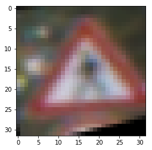

```python
plt.imshow(X_fake_trans[100])
```

```python
pd.value_counts(y_fake_trans).sort_index()
```

```
0     1320
3      240
6     1140
7      210
8      240
9      180
11     330
14     810
15     960
16    1140
17     510
18     420
19    1320
20    1200
21    1230
```

[output cut: 21 more lines]

### Data augmentation for the original data

```python
X_train.shape
```

```
(34799, 32, 32, 3)
```

```python
#这个函数转换原始的34799张图片
# 使用了normalization
def transform_origin_data(X_train,y_train,N_classes,
                          ang_range,shear_range,trans_range,brightness,randomize_Var=0,
                          n_each=1):
    '''
    Usage: This is used to perform augmentation on original data.
    Arg:
    X_train: input image data set,shape=(num_examples, 32, 32, 3)
    y_train: lables of the input image, shape=(num_examples,)

    N_classes: num of classes
    n_each:  default=1 and one is enough, as we just want to distort each original img once.
    the upper scale of examples that we want to compensate for those y_train_fake_class

    ang_range,shear_range,trans_range,brightness: the args of the transform_image function
    randomize_Var: whether shuffle the img data
    '''

    dict_indices = get_index_dict(y_train)
    n_class = len(np.unique(y_train))
    X_arr = []
    Y_arr = []
    n_train = len(X_train)
    for i in range(n_train):
        #X_arr.append(transform_image(X_train[i],0,0,0)/255.)
        #Y_arr.append(y_train[i])
        for i_n in range(n_each):
            img_trf = transform_image(X_train[i],
                                      ang_range,shear_range,trans_range,brightness,norm=0)
            X_arr.append(img_trf)
            Y_arr.append(y_train[i])

    X_arr = np.array(X_arr,dtype = np.uint8())
    Y_arr = np.array(Y_arr,dtype = np.int32())

    if (randomize_Var == 1):
        #len_arr = np.arange(len(Y_arr))
        #np.random.shuffle(len_arr)
        #X_arr[len_arr] = X_arr
        #Y_arr[len_arr] = Y_arr
        X_arr, Y_arr = shuffle(X_arr, Y_arr)

    #labels_arr = OHE_labels(Y_arr,43)

    return X_arr,Y_arr#,labels_arr
```

```python
X_org_trans,y_org_trans=transform_origin_data(X_train,y_train,
                                            N_classes=43,n_each=1,
                                            ang_range=20,shear_range=10,trans_range=5,brightness=1,
                                            randomize_Var=1)
```

```python
X_org_trans.shape
```

```
(34799, 32, 32, 3)
```

```python
plt.figure(figsize=(1,1))
plt.imshow(X_org_trans[30901])
plt.axis('off')
print("The class num is: %d" %y_org_trans[30901])
```

[output not shown]

```
The class num is: 13
```

### Concat fake data and original transformed data

```python
X_train_new=np.concatenate((X_org_trans,X_fake_trans))
y_train_new=np.concatenate((y_org_trans,y_fake_trans))
```

```python
X_train_new=np.concatenate((X_train_new,X_train))
y_train_new=np.concatenate((y_train_new,y_train))
```

```python
X_train_new.shape,X_train.shape
```

```
((102179, 32, 32, 3), (34799, 32, 32, 3))
```

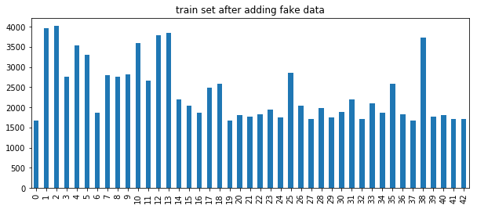

```python
y_train_new_vis=pd.value_counts(y_train_new).sort_index()
y_train_new_vis.plot(kind='bar',figsize=(10,4),title='train set after adding fake data')
```

### Model Architecture

```python
from datetime import datetime
import time
```

```python
### Define your architecture here.
### Feel free to use as many code cells as needed.
### shuffle data again
from sklearn.utils import shuffle
#X_train, y_train = shuffle(X_train, y_train)
X_train, y_train = shuffle(X_train_new, y_train_new)
```

```python
import tensorflow as tf

EPOCHS = 100
BATCH_SIZE = 512 #256
NUM_CLASSES = 43
```

```python
X_valid.shape
```

```
(4410, 32, 32, 3)
```

#### A btter way is to define a batch generator(To do)

```python
#batch norm
def batch_norm(x, n_out):      #patrick added on 2017-02-20
    """
    Batch normalization on convolutional maps.
    Ref.: http://stackoverflow.com/questions/33949786/how-could-i-use-batch-normalization-in-tensorflow
    Args:
        x:           Tensor, 4D BHWD input maps
        n_out:       integer, depth of input maps
        phase_train: boolean tf.Varialbe, true indicates training phase
        scope:       string, variable scope
    Return:
        normed:      batch-normalized maps
    """
    with tf.variable_scope('bn'):
        beta = tf.Variable(tf.constant(0.0, shape=[n_out]),
                                     name='beta', trainable=True)
        gamma = tf.Variable(tf.constant(1.0, shape=[n_out]),
                                      name='gamma', trainable=True)
        batch_mean, batch_var = tf.nn.moments(x, [0,1,2], name='moments')
        ema = tf.train.ExponentialMovingAverage(decay=0.5)
        #ema = tf.train.ExponentialMovingAverage(decay=MOVING_AVERAGE_DECAY)

        def mean_var_with_update():
            ema_apply_op = ema.apply([batch_mean, batch_var])
            with tf.control_dependencies([ema_apply_op]):
                return tf.identity(batch_mean), tf.identity(batch_var)

        def mean_var():
            return ema.average(batch_mean), ema.average(batch_var)

        mean, var=mean_var_with_update()

        normed = tf.nn.batch_normalization(x, mean, var, beta, gamma, 1e-3)
    return normed
```

```python
from tensorflow.contrib.layers import flatten

def LeNet(x, keep_prob=0.5):
    # Arguments used for tf.truncated_normal, randomly defines variables for the weights and biases for each layer
    mu = 0
    sigma = 0.1

    # SOLUTION: Layer 1: Convolutional. Input = 32x32x3. Output = 32*32x16.
    conv1_W = tf.Variable(tf.truncated_normal(shape=(5, 5, 3, 16), mean = mu, stddev = sigma))
    conv1_b = tf.Variable(tf.zeros(16))
    conv1   = tf.nn.conv2d(x, conv1_W, strides=[1, 1, 1, 1], padding='SAME') + conv1_b
    conv1   =  batch_norm(conv1, 16)   #patrick modified


    # SOLUTION: Activation.
    conv1_activation = tf.nn.relu(conv1)


    # pool1  output.shape=[32/2=16*16*16]
    conv1 = tf.nn.max_pool(conv1_activation, ksize=[1, 2, 2, 1], strides=[1, 2, 2, 1],
                         padding='SAME', name='pool1')

    # SOLUTION: Layer 2: Convolutional.   Output.shape=16*16*32
    conv2_W = tf.Variable(tf.truncated_normal(shape=(5, 5, 16, 32), mean = mu, stddev = sigma))
    conv2_b = tf.Variable(tf.zeros(32))
    conv2   = tf.nn.conv2d(conv1, conv2_W, strides=[1, 1, 1, 1], padding='SAME') + conv2_b
    conv2   =  batch_norm(conv2, 32)   #patrick modified batch normalization


    # SOLUTION: Activation.
    conv2_activation = tf.nn.relu(conv2)


    # SOLUTION: Pooling. Input = 16*16*64. Output.shape=16/2=8*8*32.
    conv2 = tf.nn.max_pool(conv2_activation, ksize=[1, 2, 2, 1],
                         strides=[1, 2, 2, 1], padding='SAME', name='pool2')  #output.shape=16/2=8*8*64

    # SOLUTION: Layer 3: Convolutional.   Output.shape=8*8*64
    conv3_W = tf.Variable(tf.truncated_normal(shape=(3, 3, 32, 64), mean = mu, stddev = sigma))
    conv3_b = tf.Variable(tf.zeros(64))
    conv3   = tf.nn.conv2d(conv2, conv3_W, strides=[1, 1, 1, 1], padding='SAME') + conv3_b
    conv3   =  batch_norm(conv3, 64)   #patrick modified batch normalization


    # SOLUTION: Activation.
    #conv3 = tf.nn.relu(conv3)


    # SOLUTION: Activation.
    conv3_activation = tf.nn.relu(conv3)

    # SOLUTION: Pooling. Input = 8*8*64. Output.shape=8/2=4*4*64=1024.
    conv3 = tf.nn.max_pool(conv3_activation, ksize=[1, 2, 2, 1],
                         strides=[1, 2, 2, 1], padding='SAME', name='pool3')  #output.shape=16/2=8*8*64

    # SOLUTION: Flatten. Input = 4*4*64. Output = 1024.
    fc0   = flatten(conv3)


    # SOLUTION: Layer 4: Fully Connected. Input = 1024. Output = 512.
    fc1_W = tf.Variable(tf.truncated_normal(shape=(1024, 512), mean = mu, stddev = sigma))
    fc1_b = tf.Variable(tf.zeros(512))
    fc1   = tf.matmul(fc0, fc1_W) + fc1_b

    # SOLUTION: Activation.
    fc1    = tf.nn.relu(fc1)

    #dropout p=50%   patrick modified
    #keep_prob = keep_prob
    fc1 = tf.nn.dropout(fc1, keep_prob)

    # SOLUTION: Layer 5: Fully Connected. Input = 512. Output = 360.
    fc2_W  = tf.Variable(tf.truncated_normal(shape=(512, 360), mean = mu, stddev = sigma))
    fc2_b  = tf.Variable(tf.zeros(360))
    fc2    = tf.matmul(fc1, fc2_W) + fc2_b
    #logits = tf.add(tf.matmul(fc1, fc2_W), fc2_b)


    # SOLUTION: Activation.
    fc2    = tf.nn.relu(fc2)

    #dropout p=50%   patrick modified
    #keep_prob = keep_prob
    fc2 = tf.nn.dropout(fc2, keep_prob)

    # SOLUTION: Layer 6: Fully Connected. Input = 360. Output = 43.
    fc3_W  = tf.Variable(tf.truncated_normal(shape=(360, 43), mean = mu, stddev = sigma))
    fc3_b  = tf.Variable(tf.zeros(43))
    logits = tf.add(tf.matmul(fc2, fc3_W), fc3_b)

    return logits,conv1,conv2,conv3,conv1_activation,conv2_activation,conv3_activation
```

```python
x = tf.placeholder(tf.float32, (None, 32, 32, 3))
y = tf.placeholder(tf.int32, (None))
one_hot_y = tf.one_hot(y, 43)
keep_prob=tf.placeholder(tf.float32)
```

```python
rate = 0.001
logits,conv1,conv2,conv3,conv1_activation,conv2_activation,conv3_activation = LeNet(x,keep_prob)

cross_entropy = tf.nn.softmax_cross_entropy_with_logits(logits=logits, labels=one_hot_y)
loss_operation = tf.reduce_mean(cross_entropy)
optimizer = tf.train.AdamOptimizer(learning_rate = rate)
training_operation = optimizer.minimize(loss_operation)
```

```python
correct_prediction = tf.equal(tf.argmax(logits, 1), tf.argmax(one_hot_y, 1))
accuracy_operation = tf.reduce_mean(tf.cast(correct_prediction, tf.float32))
saver = tf.train.Saver()

def evaluate(X_data, y_data,kp):
    num_examples = len(X_data)
    total_accuracy = 0
    sess = tf.get_default_session()
    for offset in range(0, num_examples, BATCH_SIZE):
        batch_x, batch_y = X_data[offset:offset+BATCH_SIZE], y_data[offset:offset+BATCH_SIZE]
        accuracy = sess.run(accuracy_operation, feed_dict={x: batch_x, y: batch_y,keep_prob:kp})
        total_accuracy += (accuracy * len(batch_x))
    return total_accuracy / num_examples
```

### Train, Validate and Test the Model

A validation set can be used to assess how well the model is performing. A low accuracy on the training and validation sets imply underfitting. A high accuracy on the training set but low accuracy on the validation set implies overfitting.

```python
best_validation_accuracy = 0.0
last_improvement_epoch = 0
require_improvement_epoch = 10
val_acc_list=[]
train_acc_list=[]
```

```python
with tf.Session() as sess:
    sess.run(tf.global_variables_initializer())
    num_examples = len(X_train)

    print("Training...")
    print()
    for i in range(EPOCHS):
        start_time = time.time()
        X_train, y_train = shuffle(X_train, y_train)
        for offset in range(0, num_examples, BATCH_SIZE):
            end = offset + BATCH_SIZE
            batch_x, batch_y = X_train[offset:end], y_train[offset:end]
            sess.run(training_operation, feed_dict={x: batch_x, y: batch_y, keep_prob: 0.5})

        kp=1.0
        train_accuracy=evaluate(batch_x,batch_y, kp)
        validation_accuracy = evaluate(X_valid, y_valid, kp)
        duration = time.time() - start_time
        print("EPOCH {} ...".format(i+1))
        print("Train Accuracy = {:.3f}".format(train_accuracy))
        print("Validation Accuracy = {:.3f}".format(validation_accuracy))
        print("%s Epoch Duration is: %.3f" % (datetime.now(), duration))
        print()

        #Early Stop
        #acc_batch = session.run(accuracy, feed_dict=feed_dict_batch)
        #acc_valid = session.run(accuracy,feed_dict=feed_dict_valid)
        val_acc_list.append(validation_accuracy)
        train_acc_list.append(train_accuracy)

        if  i>=30:
            if  validation_accuracy > best_validation_accuracy:
                best_validation_accuracy = validation_accuracy
                last_improvement_epoch = i
                improved_str = '*'
                saver = tf.train.Saver()
                saver.save(sess, save_path='model_best_ckpt')
                print("Model saved")
                print()
            else:
                improved_str = ''

            if i - last_improvement_epoch > require_improvement_epoch:
                print ("No improvement for %d Epoches, Early Stopping @ Epoch %d" %(require_improvement_epoch,i+1))
                print ("The best valid acc is %.3f" %np.max(val_acc_list))
                break

    #saver.save(sess, './lenet')
    #print("Model saved")
```

```
Training...

EPOCH 1 ...
Train Accuracy = 0.244
Validation Accuracy = 0.256
2017-04-04 14:00:32.952105 Epoch Duration is: 16.549

EPOCH 2 ...
Train Accuracy = 0.375
Validation Accuracy = 0.391
2017-04-04 14:00:49.102833 Epoch Duration is: 16.150

EPOCH 3 ...
Train Accuracy = 0.478
Validation Accuracy = 0.472
2017-04-04 14:01:05.264766 Epoch Duration is: 16.162

EPOCH 4 ...
Train Accuracy = 0.536
Validation Accuracy = 0.525
2017-04-04 14:01:21.434050 Epoch Duration is: 16.169

EPOCH 5 ...
Train Accuracy = 0.601
Validation Accuracy = 0.593
2017-04-04 14:01:37.614594 Epoch Duration is: 16.180

EPOCH 6 ...
Train Accuracy = 0.643
Validation Accuracy = 0.651
2017-04-04 14:01:53.792972 Epoch Duration is: 16.178

EPOCH 7 ...
Train Accuracy = 0.711
Validation Accuracy = 0.732
2017-04-04 14:02:09.962023 Epoch Duration is: 16.169

EPOCH 8 ...
Train Accuracy = 0.756
Validation Accuracy = 0.728
```

[output cut: 478 more lines]

```

EPOCH 98 ...
Train Accuracy = 1.000
Validation Accuracy = 0.949
2017-04-04 14:27:24.108376 Epoch Duration is: 16.066

EPOCH 99 ...
Train Accuracy = 1.000
Validation Accuracy = 0.953
2017-04-04 14:27:40.202790 Epoch Duration is: 16.094

EPOCH 100 ...
Train Accuracy = 1.000
Validation Accuracy = 0.949
2017-04-04 14:27:56.285435 Epoch Duration is: 16.082
```

```python
### Validation on the test set
```

```python
with tf.Session() as sess:
    #saver.restore(sess, tf.train.latest_checkpoint('.'))   #用这句也可以restore
    saver.restore(sess, './model_best_ckpt')
    kp = 1.0
    test_accuracy = evaluate(X_test, y_test,kp)
    print("Test Accuracy = {:.3f}".format(test_accuracy))

    #sess.close()

#saver.save(sess=session, save_path='model_best_test')
```

```
Test Accuracy = 0.949
```

## Step 3: Test a Model on New Images

To give yourself more insight into how your model is working, download at least five pictures of German traffic signs from the web and use your model to predict the traffic sign type.

You may find `signnames.csv` useful as it contains mappings from the class id (integer) to the actual sign name.

### Load and Output the Images

```python
import os
```

```python
### Load the images and plot them here.
### Feel free to use as many code cells as needed.
def process_newimage_file(name):
    image = cv2.imread(name)
    image = cv2.resize(image,(32,32))
    image = cv2.cvtColor(image,cv2.COLOR_BGR2RGB)
    #image = image/255.-.5
    return image

def plot_newImage_3C(n_row,n_col,X):

    plt.figure(figsize = (8,6))
    gs1 = gridspec.GridSpec(n_row,n_row)
    gs1.update(wspace=0.01, hspace=0.02) # set the spacing between axes.

    for i in range(n_row*n_col):
        # i = i + 1 # grid spec indexes from 0

        ax1 = plt.subplot(gs1[i])
        plt.axis('on')
        ax1.set_xticklabels([])
        ax1.set_yticklabels([])
        ax1.set_aspect('equal')
        #plt.subplot(4,11,i+1)

        ind_plot = i
        plt.imshow(X[ind_plot])
        plt.axis('off')
    plt.show()
```

```python
newdata = [process_newimage_file("./genman_traffic_signs_unseen/"+name) for name in os.listdir("./genman_traffic_signs_unseen/")]
namenewdata = [name for name in os.listdir("./genman_traffic_signs_unseen/")]
#newdata = np.array(newdata ,dtype = np.float32)
```

```python
namenewdata
```

```
['test5.jpg',
 'test4.jpg',
 'test8.jpg',
 'test1.jpg',
 'test2.jpg',
 'test6.jpg',
 'test3.jpg',
 'test7.jpg']
```

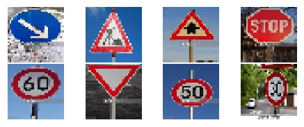

```python
plot_newImage_3C(4,2,newdata)
```

### Predict the Sign Type for Each Image

```python
#define the softmax tensor
labels_pred = tf.nn.softmax(logits)
```

```python
### Run the predictions here and use the model to output the prediction for each image.
### Make sure to pre-process the images with the same pre-processing pipeline used earlier.
### Feel free to use as many code cells as needed.
with tf.Session() as sess:
    saver.restore(sess, tf.train.latest_checkpoint('.'))
    feed_dict_new = {x:newdata,keep_prob: 1.0}
    top5 = tf.nn.top_k(labels_pred, 5)

    predictions = sess.run(labels_pred,feed_dict = feed_dict_new)
    top5_pred = sess.run([labels_pred, top5], feed_dict=feed_dict_new)
```

```python
#explore the top 5 softmax prob and the related classes
top5_pred[1]
```

```
TopKV2(values=array([[  1.00000000e+00,   1.98089551e-13,   2.52031435e-14,
          1.60103404e-15,   1.11455126e-15],
       [  9.99760568e-01,   1.92335792e-04,   2.63939273e-05,
          2.00250524e-05,   7.11894927e-07],
       [  9.66617703e-01,   3.33700851e-02,   1.09266011e-05,
          1.17083380e-06,   7.25290263e-08],
       [  1.00000000e+00,   9.42612099e-11,   8.32356961e-11,
          2.28395393e-16,   1.27802804e-17],
       [  9.96277750e-01,   3.70329223e-03,   1.65988949e-05,
          1.55157784e-06,   2.35921661e-07],
       [  1.00000000e+00,   1.05634821e-21,   3.64817801e-22,
          3.17740906e-24,   5.36098531e-26],
       [  9.35034215e-01,   3.13751921e-02,   1.28501374e-02,
          5.91583690e-03,   4.12460975e-03],
       [  4.26553190e-01,   3.47160190e-01,   1.08584814e-01,
          6.94331601e-02,   3.35606374e-02]], dtype=float32), indices=array([[38, 36, 34, 39, 40],
       [25, 24, 29, 18, 26],
       [11, 30, 17, 16,  7],
       [14, 29, 17, 15,  5],
       [ 3, 15,  5,  9,  1],
       [13, 12, 15, 17, 10],
       [ 1,  8,  2,  4,  7],
       [20, 26, 19, 22, 11]], dtype=int32))
```

```python
data_pd = pd.read_csv('signnames.csv')
```

```python
newdata_dict={'test1.jpg':14,
 'test2.jpg':3,
 'test3.jpg':2,
 'test4.jpg':25,
 'test5.jpg':38,
 'test6.jpg':13,
 'test7.jpg':1,
 'test8.jpg':11}
```

```python
data_pd
```

|  | ClassId | SignName |
| --- | --- | --- |
| 0 | 0 | Speed limit (20km/h) |
| 1 | 1 | Speed limit (30km/h) |
| 2 | 2 | Speed limit (50km/h) |
| 3 | 3 | Speed limit (60km/h) |
| 4 | 4 | Speed limit (70km/h) |
| 5 | 5 | Speed limit (80km/h) |
| 6 | 6 | End of speed limit (80km/h) |
| 7 | 7 | Speed limit (100km/h) |
| 8 | 8 | Speed limit (120km/h) |
| 9 | 9 | No passing |
| 10 | 10 | No passing for vehicles over 3.5 metric tons |
| 11 | 11 | Right-of-way at the next intersection |
| 12 | 12 | Priority road |
| 13 | 13 | Yield |
| 14 | 14 | Stop |
| 15 | 15 | No vehicles |
| 16 | 16 | Vehicles over 3.5 metric tons prohibited |
| 17 | 17 | No entry |
| 18 | 18 | General caution |
| 19 | 19 | Dangerous curve to the left |
| 20 | 20 | Dangerous curve to the right |
| 21 | 21 | Double curve |
| 22 | 22 | Bumpy road |
| 23 | 23 | Slippery road |
| 24 | 24 | Road narrows on the right |
| 25 | 25 | Road work |
| 26 | 26 | Traffic signals |
| 27 | 27 | Pedestrians |
| 28 | 28 | Children crossing |
| 29 | 29 | Bicycles crossing |
| 30 | 30 | Beware of ice/snow |
| 31 | 31 | Wild animals crossing |
| 32 | 32 | End of all speed and passing limits |
| 33 | 33 | Turn right ahead |
| 34 | 34 | Turn left ahead |
| 35 | 35 | Ahead only |
| 36 | 36 | Go straight or right |
| 37 | 37 | Go straight or left |
| 38 | 38 | Keep right |
| 39 | 39 | Keep left |
| 40 | 40 | Roundabout mandatory |
| 41 | 41 | End of no passing |
| 42 | 42 | End of no passing by vehicles over 3.5 metric ... |

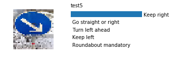

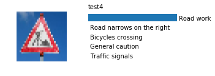

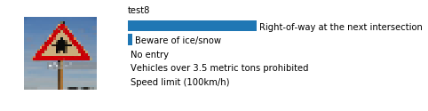

[figure not shown]

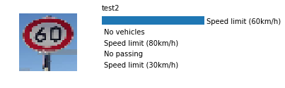

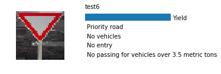

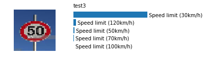

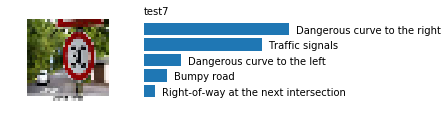

```python
for i in range(8):
    plt.figure(figsize = (5,1.5))
    gs = gridspec.GridSpec(1, 2,width_ratios=[2,3])
    plt.subplot(gs[0])
    plt.imshow(newdata[i])
    plt.axis('off')
    plt.subplot(gs[1])
    plt.barh(6-np.arange(5),top5_pred[1][0][i], align='center')
    for i_label in range(5):
        plt.text(top5_pred[1][0][i][i_label]+.02,6-i_label-.25,
                 #data_pd['ClassId'][top5_pred[1][1][i][i_label]],
            data_pd['SignName'][top5_pred[1][1][i][i_label]])
    plt.axis('off');
    plt.text(0,6.95,namenewdata[i].split('.')[0]);
    plt.show();
```

### Analyze Performance

```python
newdata_dict
```

```
{'test1.jpg': 14,
 'test2.jpg': 3,
 'test3.jpg': 2,
 'test4.jpg': 25,
 'test5.jpg': 38,
 'test6.jpg': 13,
 'test7.jpg': 1,
 'test8.jpg': 11}
```

```python
### Calculate the accuracy for these 8 new images.
### For example, if the model predicted 1 out of 5 signs correctly, it's 20% accurate on these new images.
X_unseen=newdata.copy()
y_unseen=[]
for i in namenewdata:
    y_new=newdata_dict[i]
    y_unseen.append(y_new)
```

```python
with tf.Session() as sess:
    #saver.restore(sess, tf.train.latest_checkpoint('.'))   #用这句也可以restore
    saver.restore(sess, './model_best_ckpt')
    kp = 1.0
    unseen_accuracy = evaluate(X_unseen, y_unseen,kp)
    print("Unseen Accuracy = {:.3f}".format(unseen_accuracy))
```

```
Unseen Accuracy = 0.750
```

### Output Top 5 Softmax Probabilities For Each Image Found on the Web

For each of the new images, print out the model's softmax probabilities to show the **certainty** of the model's predictions (limit the output to the top 5 probabilities for each image). [`tf.nn.top_k`](https://www.tensorflow.org/versions/r0.12/api_docs/python/nn.html#top_k) could prove helpful here.

The example below demonstrates how tf.nn.top_k can be used to find the top k predictions for each image.

`tf.nn.top_k` will return the values and indices (class ids) of the top k predictions. So if k=3, for each sign, it'll return the 3 largest probabilities (out of a possible 43) and the correspoding class ids.

Take this numpy array as an example. The values in the array represent predictions. The array contains softmax probabilities for five candidate images with six possible classes. `tk.nn.top_k` is used to choose the three classes with the highest probability:

```
# (5, 6) array
a = np.array([[ 0.24879643,  0.07032244,  0.12641572,  0.34763842,  0.07893497,
         0.12789202],
       [ 0.28086119,  0.27569815,  0.08594638,  0.0178669 ,  0.18063401,
         0.15899337],
       [ 0.26076848,  0.23664738,  0.08020603,  0.07001922,  0.1134371 ,
         0.23892179],
       [ 0.11943333,  0.29198961,  0.02605103,  0.26234032,  0.1351348 ,
         0.16505091],
       [ 0.09561176,  0.34396535,  0.0643941 ,  0.16240774,  0.24206137,
         0.09155967]])
```

Running it through `sess.run(tf.nn.top_k(tf.constant(a), k=3))` produces:

```
TopKV2(values=array([[ 0.34763842,  0.24879643,  0.12789202],
       [ 0.28086119,  0.27569815,  0.18063401],
       [ 0.26076848,  0.23892179,  0.23664738],
       [ 0.29198961,  0.26234032,  0.16505091],
       [ 0.34396535,  0.24206137,  0.16240774]]), indices=array([[3, 0, 5],
       [0, 1, 4],
       [0, 5, 1],
       [1, 3, 5],
       [1, 4, 3]], dtype=int32))
```

Looking just at the first row we get `[ 0.34763842, 0.24879643, 0.12789202]`, you can confirm these are the 3 largest probabilities in `a`. You'll also notice `[3, 0, 5]` are the corresponding indices.

### please see the cell ahead which include the top 5 accuracy

```python
### Print out the top five softmax probabilities for the predictions on the German traffic sign images found on the web.
### Feel free to use as many code cells as needed.
```

## Step 4: Visualize the Neural Network's State with Test Images

This Section is not required to complete but acts as an additional excersise for understaning the output of a neural network's weights. While neural networks can be a great learning device they are often referred to as a black box. We can understand what the weights of a neural network look like better by plotting their feature maps. After successfully training your neural network you can see what it's feature maps look like by plotting the output of the network's weight layers in response to a test stimuli image. From these plotted feature maps, it's possible to see what characteristics of an image the network finds interesting. For a sign, maybe the inner network feature maps react with high activation to the sign's boundary outline or to the contrast in the sign's painted symbol.

Provided for you below is the function code that allows you to get the visualization output of any tensorflow weight layer you want. The inputs to the function should be a stimuli image, one used during training or a new one you provided, and then the tensorflow variable name that represents the layer's state during the training process, for instance if you wanted to see what the LeNet lab's feature maps looked like for it's second convolutional layer you could enter conv2 as the tf_activation variable.

For an example of what feature map outputs look like, check out NVIDIA's results in their paper [End-to-End Deep Learning for Self-Driving Cars](https://devblogs.nvidia.com/parallelforall/deep-learning-self-driving-cars/) in the section Visualization of internal CNN State. NVIDIA was able to show that their network's inner weights had high activations to road boundary lines by comparing feature maps from an image with a clear path to one without. Try experimenting with a similar test to show that your trained network's weights are looking for interesting features, whether it's looking at differences in feature maps from images with or without a sign, or even what feature maps look like in a trained network vs a completely untrained one on the same sign image.

[figure not shown]

Your output should look something like this (above)

```python
### Visualize your network's feature maps here.
### Feel free to use as many code cells as needed.

# image_input: the test image being fed into the network to produce the feature maps
# tf_activation: should be a tf variable name used during your training procedure that represents the calculated state of a specific weight layer
# activation_min/max: can be used to view the activation contrast in more detail, by default matplot sets min and max to the actual min and max values of the output
# plt_num: used to plot out multiple different weight feature map sets on the same block, just extend the plt number for each new feature map entry

def outputFeatureMap(image_input, tf_activation, activation_min=-1, activation_max=-1 ,plt_num=1):
    # Here make sure to preprocess your image_input in a way your network expects
    # with size, normalization, ect if needed
    # image_input =
    # Note: x should be the same name as your network's tensorflow data placeholder variable
    # If you get an error tf_activation is not defined it maybe having trouble accessing the variable from inside a function
    activation = tf_activation.eval(session=sess,feed_dict={x : image_input, keep_prob:1.0})
    featuremaps = activation.shape[3]
    plt.figure(plt_num, figsize=(20,25))
    for featuremap in range(featuremaps):
        plt.subplot(8,8, featuremap+1) # sets the number of feature maps to show on each row and column
        plt.title('FeatureMap ' + str(featuremap)) # displays the feature map number

        if activation_min != -1 & activation_max != -1:
            plt.imshow(activation[0,:,:, featuremap], interpolation="nearest", vmin =activation_min, vmax=activation_max, cmap="gray")
        elif activation_max != -1:
            plt.imshow(activation[0,:,:, featuremap], interpolation="nearest", vmax=activation_max, cmap="gray")
        elif activation_min !=-1:
            plt.imshow(activation[0,:,:, featuremap], interpolation="nearest", vmin=activation_min, cmap="gray")
        else:
            plt.imshow(activation[0,:,:, featuremap], interpolation="nearest", cmap="gray")
```

```python
feature_map_input=np.reshape(newdata[0],(1,32,32,-1))
feature_map_input.shape
```

```
(1, 32, 32, 3)
```

```python
conv1.shape
```

```
TensorShape([Dimension(None), Dimension(16), Dimension(16), Dimension(16)])
```

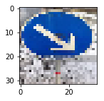

```python
plt.figure(figsize=(2,2))
plt.imshow(newdata[0])
```

### Feature maps after max pooling

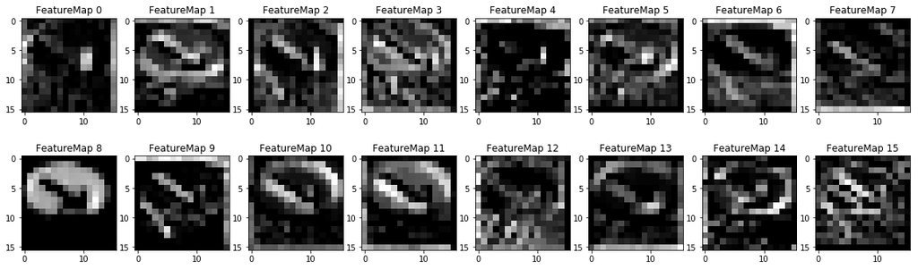

```python
with tf.Session() as sess:
    saver.restore(sess, tf.train.latest_checkpoint('.'))
    outputFeatureMap(feature_map_input,conv1)
```

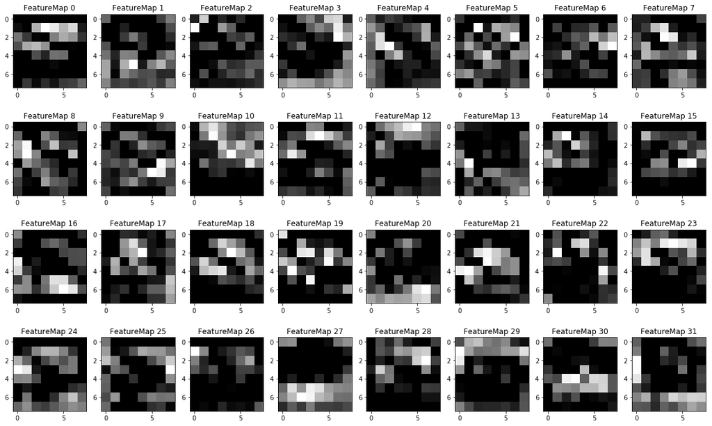

```python
with tf.Session() as sess:
    saver.restore(sess, tf.train.latest_checkpoint('.'))
    outputFeatureMap(feature_map_input,conv2)
```

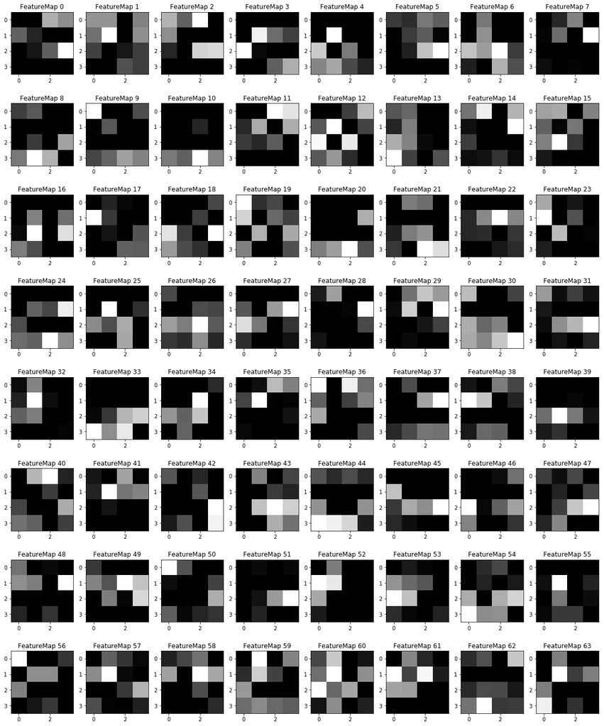

```python
with tf.Session() as sess:
    saver.restore(sess, tf.train.latest_checkpoint('.'))
    outputFeatureMap(feature_map_input,conv3)
```

### Feature maps after activation

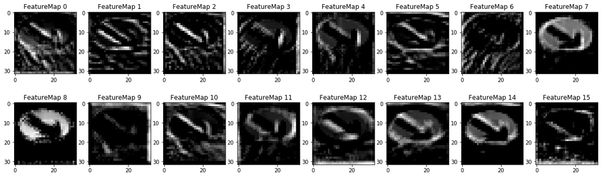

```python
with tf.Session() as sess:
    saver.restore(sess, tf.train.latest_checkpoint('.'))
    outputFeatureMap(feature_map_input,conv1_activation)
```

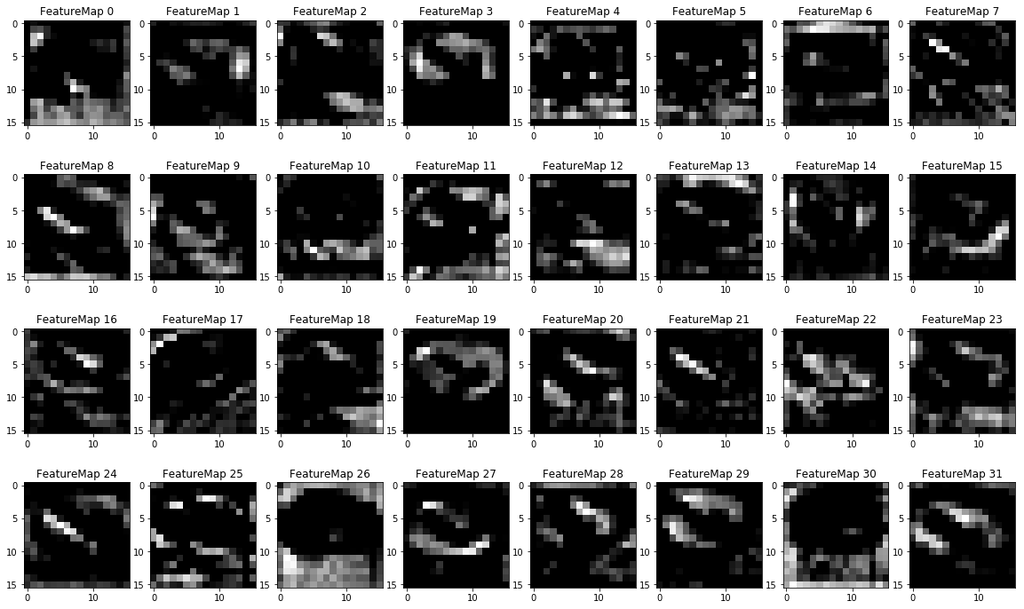

```python
with tf.Session() as sess:
    saver.restore(sess, tf.train.latest_checkpoint('.'))
    outputFeatureMap(feature_map_input,conv2_activation)
```

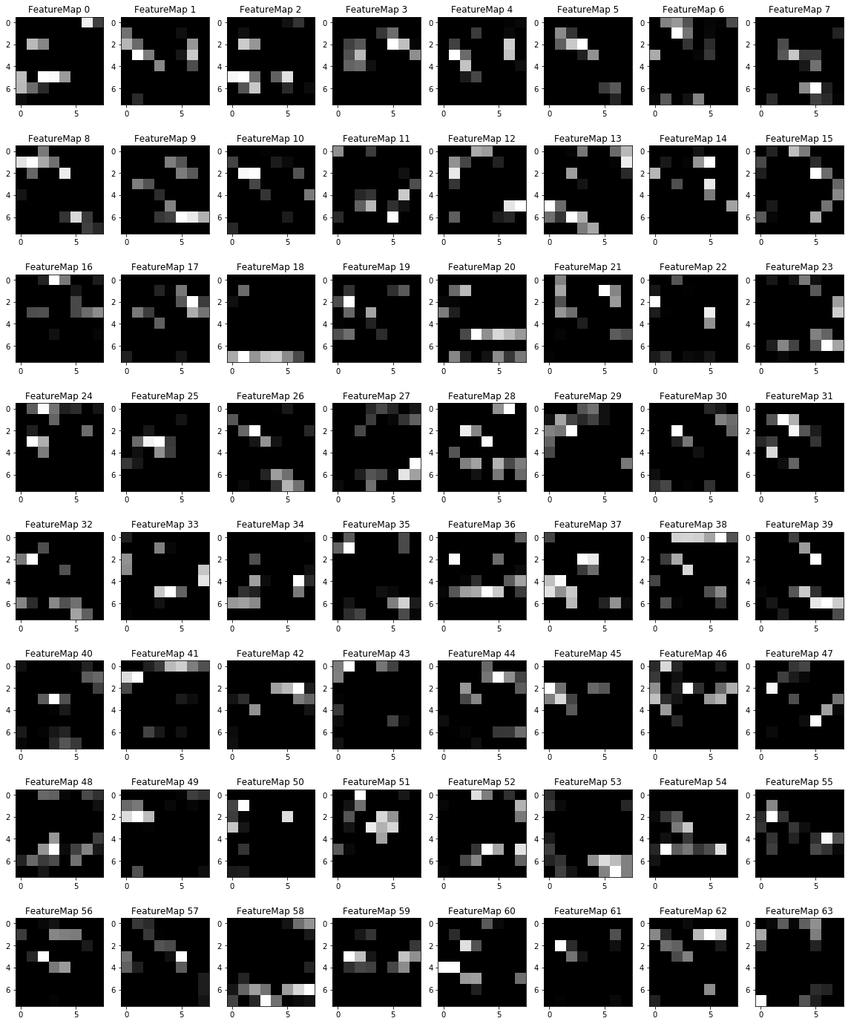

```python
with tf.Session() as sess:
    saver.restore(sess, tf.train.latest_checkpoint('.'))
    outputFeatureMap(feature_map_input,conv3_activation)
```

### Question 9

Discuss how you used the visual output of your trained network's feature maps to show that it had learned to look for interesting characteristics in traffic sign images

### Project Writeup

Once you have completed the code implementation, document your results in a project writeup using this [template](https://github.com/udacity/CarND-Traffic-Sign-Classifier-Project/blob/master/writeup_template.md) as a guide. The writeup can be in a markdown or pdf file.